# P24-203

Gene expression analysis in single-nuclei RNA-seq data

Kristina Benevides

2025-02-25

# 1 Introduction

This project is aiming to analyse public sequencing data, specifically snRNA sequencing data. We aim to investigate whether two different genes (GFRAL and Adcyap1) are expressed in the same cells or not from an area of the brain called dorsal vagal complex (DVC), which is mainly formed by two regions, the area postrema (AP) and the nucleus of the tractus solitarii (NTS).

# 2 Methods

**Methods**

## 2.1 The Data

- The GSE166649 data set from Ludwig et al. (2021) consists of 20 snRNA-seq samples, split into 50 files. Prepped with Chromium 10X 3’ v2. Some are sequenced on NextSeq and are split into four files, while other samples are sequenced on NovaSeq and split into two files. Based on the file names I assume the samples come from different batches collected during a period of about five-six months.
- The GSE206144 data set from Ilanges et al. (2022) consists of six sample, of which three are cell hashing libraries (HTO) and the rest are transcriptomics libraries. Library prep used was 10X Chromium v3.

## 2.2 Data processing

### 2.2.1 Pre-processing

All sampels were downloaded and pre-processed using the pipeline nf-core/scrnaseq v.2.7.1](https://nf-co.re/scrnaseq/2.7.1/) running with cellranger v 8.0.0.

### 2.2.2 QC

After looking at the multiqc report, I could conclude that:

- Most samples only had roughly half of the expected number of cells (or I misunderstood the authors when they wrote “9,000 nuclei were used for snRNA-seq and snATAC–seq“, I took it as they have used 9,000 nuclei for the snRNA-seq and 9,000 nuclei for the snATAC-seq. Perhaps they meant 9,000 nuclei in total were used for BOTH snRNA-seq and snATAC-seq. Then the number of cells are as approximately as expected for the majority of samples).
- Around 80-90% of the reads are mapped, with around 30-50% mapping to exonic regions. This is expected since we’re working with single-nuclei data and typically therefore see a high percentage of reads coming from unspliced transcripts which align to introns.
- The median number of genes per cell is 500-1,500, which is fine. The saturation plot suggests that some samples are under sequenced, and we might be missing some lowly expressed genes in there.
- The barcode knee plot indicate high contamination of ambient RNA (according to 10X). Since there’re no clear cliffs in the plots, just removing empty empty droplets based on a hard UMI threshold probably isn’t sufficient. Using tools like CellBender, SoupX or DecontX are to prefer since they can model the data when proven difficult to distinguish empty droplets from cell-containing ones.The two samples from GSE206144 have notably better quality than the samples from GSE166649, and those two samples actually wouldn’t need ambient RNA removal but I will include them as well to be consistent.

### 2.2.3 Ambient RNA removal

In droplet-based single-cell RNA sequencing, some background (ambient) mRNA is always present in the solution. This mRNA can end up in the droplets along with the cells and get sequenced. As a result, some of the detected gene expression comes from the surrounding solution rather than the cell inside the droplet. SoupX was used to remove the ambient RNA. I investigated the change in expression due to this correction for our genes of interest (Fig 2.1). It shows the fraction of expression in each cell that has been deemed to be soup and removed. Please note that the figures are just examples from ONE sample, and this was done for all 22 samples. As you can see for Adcyap1, the expression in some clusters have been heavily decreased. The interpretation of cell expression can change a lot after contamination correction.

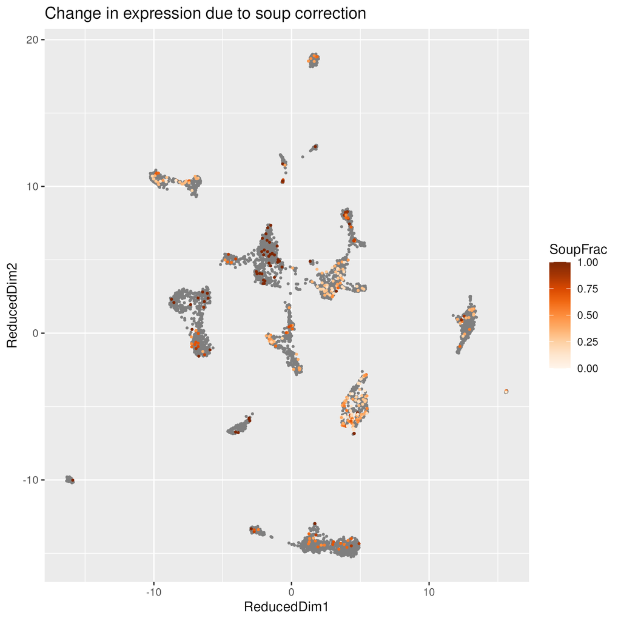

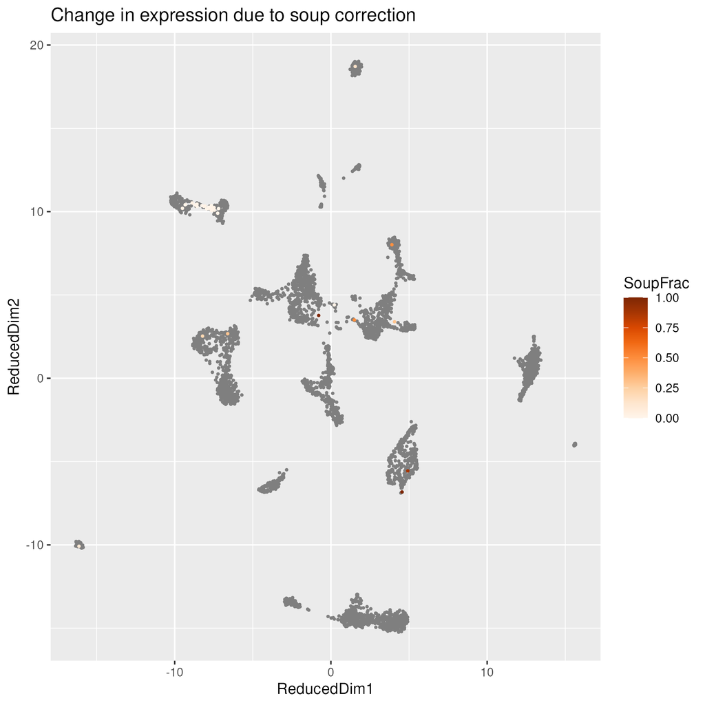

### 2.2.5 Data integration

The two datasets were integrated using Harmony.

# 3 Results

## 3.1 Clustering and annotation

Annotation was done using gene marker list from literature (…) and the R-package [AUCell](https://bioconductor.org/packages/release/bioc/html/AUCell.html).This method ranks genes by their expression values within each cell and constructs a response curve of the number of genes from each marker set that are present with increasing rank. It then computes the area under the curve (AUC) for each marker set, quantifying the enrichment of those markers among the most highly expressed genes in that cell. This is roughly similar to performing a Wilcoxon rank sum test between genes in and outside of the set, but involving only the top ranking genes by expression in each cell.

### 3.1.3 Neuronal cell types

I proceeded with subsetting only the neuronal cell types and proceed with further exploring the gene expressions values in these cells.

## 3.2 Expression analysis

# 4 Discussion

One caveat with this project is the cell type annotation. I noticed that in some clusters there’s a lack of clear bimodality for the corresponding label, which may indicate that its gene set is not sufficiently informative. The advantage of the AUCell approach is that it does not require reference expression values. This is particularly useful when dealing with gene sets derived from the literature like we did here or other qualitative forms of biological knowledge. The disadvantage is that information on relative expression is lost when only the marker identities are used. The net effect of ignoring expression values is difficult to predict; for example, it may reduce performance for resolving more subtle cell types, but may also improve performance if the per-cell expression was too noisy to be useful. Performance is also highly dependent on the gene sets themselves.

# 5 Conclusion

## 5.1 Code

## 5.2 Resources

Articles, books and tutorials I used for this project:

- https://nf-co.re/scrnaseq/2.7.1/
- https://bioconductor.org/books/3.13/OSCA.basic/ https://www.singlecellcourse.org/index.html
- https://cran.r-project.org/web/packages/SoupX/vignettes/pbmcTutorial.html
- scLink https://academic.oup.com/gpb/article/19/3/475/7229850?login=true